# Day 4: Compare groups and describe a trend

Skip to the lesson

SMART TOOLSEcology with R and AI

DAY 04

Compare groups,  
describe a trend

0 of 6 steps checked

Check off each step as you go.  
Progress stays in this browser.

[Day 3 tutorial ↗](https://mohanb96.github.io/Ecological-data-analysis-with-R/day3_v2/)

SMART TOOLS Day 4 · ANOVA and regression

# Day 4: Compare groups and describe a trend

Mohan Bi

Smart Tools · Ecology with R and AI

On Day 2 you compared two soil treatment groups; on Day 3 you explored several fungal traits together. Today you will compare four soil treatments, then describe a numerical trend. Both analyses use a model to connect an ecological question to observations.

Beginner level · About 2 hours 10 minutes, including a break · Builds on Days 1–3

Download the student files ↓ Dataset only Starter R script

Extract the student ZIP and open its RStudio Project. Run the commands in RStudio and save them in your script. This page supplies instructions and answer checks; copy buttons do not run R.

## 0. Together first: yesterday’s R tools

**Whole class · 15 minutes.** These questions revisit [Day 3](https://mohanb96.github.io/Ecological-data-analysis-with-R/day3_v2/).

5 questions · discuss before revealing

### Question 1 · What is selected?

Read the second line in words. How many trait columns will it retain? Why should an isolate ID stay outside this numeric trait matrix?

```r
trait_names <- c("extension", "melanin", "enz_cel", "spore_abund")
trait_data <- fungi[, trait_names]
```

**Reveal answer: observations and variables**

Keep all rows and the four named trait columns. The comma separates row and column selection. An ID identifies an isolate; even a numeric-looking ID is not a measured trait and should not influence trait distances or a PCA. Different traits from one isolate do not create additional independent isolates.

### Question 2 · Keep rows aligned

What does `keep` contain? Why use the same selection for both objects?

```r
keep <- complete.cases(trait_data)
fungi_complete <- fungi[keep, ]
trait_matrix <- trait_data[keep, ]
```

**Reveal answer: one logical selection**

`keep` is a logical vector: `TRUE` where all selected trait values are observed. Applying it to both objects keeps measurements and metadata in matching order. It does not replace missing values or guarantee that the retained sample represents the excluded isolates. On Day 3, we retained 28 of 31 records.

### Question 3 · What did scale() do?

What do you expect from the second line? Does a standardised value of `+1` mean one extra raw measurement unit?

```r
trait_scaled <- scale(trait_matrix)
round(colMeans(trait_scaled), 6)
```

**Reveal answer: standardisation**

The column means should round to zero. Each column was centred and divided by its sample SD. `+1` means one SD above that trait’s mean in the retained sample, not one raw unit. Standardising does not make data normally distributed. Today we will retain soil responses in their original units so that mean differences and slopes remain directly interpretable.

### Question 4 · Two parts of a PCA result

Which command gives coordinates of isolates, and which gives trait weights? What does `[, 1:2]` select?

```r
pca_result$x[, 1:2]
pca_result$rotation[, 1:2]
```

**Reveal answer: extract the right result**

`$x` contains isolate scores; `$rotation` contains trait loadings. Both selections keep all rows and the first two columns. `$` accesses a named part of an analysis result. Today `coef()`, `confint()` and `summary()` will help us access parts of fitted models.

### Question 5 · What do the group numbers mean?

What does this request? Is group 3 necessarily more stress-tolerant than group 1?

```r
groups <- cutree(cluster_tree, k = 3)
table(groups)
```

**Reveal answer: labels and counts**

Cut the tree into three groups and count their members. Cluster numbers are arbitrary labels, not rankings of ecological performance. Asking for three groups does not prove that three natural strategies exist. Today our treatment groups are defined by the experiment, rather than created by a clustering algorithm.

I discussed the refresher and checked my explanations.

## 1. Two ecological questions, two predictor types

**Together · 10 minutes.** We return to the familiar soil microcosm dataset. Today’s analysis contains two parts: A. Compare differences among multiple groups. B. Describe a trend using a linear model.

| Analysis | Ecological question | Response | Predictor |
| --- | --- | --- | --- |
| **A · Compare groups** | How does mean aggregate stability differ among control, drought, herbicide and salinity treatments? | `WSA`, a proportion | A categorical treatment label |
| **B. Linear regression** | Across 0, 1, 2, 5 and 8 factors, how is litter mass loss associated with the number of factors? | `Decom`, a proportion | `Lv`, a numerical count |

`WSA` is water-stable aggregate proportion. `Decom` is proportional tea litter dry mass loss over the incubation.

### One modelling language

R formulas follow **`response ~ explanatory_variable`**:

- `WSA ~ treatment` estimates a separate mean for each treatment category.
- `Decom ~ Lv` estimates a straight-line mean trend across different numbers of factors.

Both are **linear models**. The one-way ANOVA is a way to examine a linear model with one categorical predictor; `aov()` provides a convenient ANOVA interface. This lesson uses ordinary linear models. Generalized linear models with other response distributions and link functions are a separate topic.

**Today’s route**

| Part | Activity | Minutes |
| --- | --- | --- |
| 0 | Whole-class R refresher | 15 |
| 1 | Two analysis parts and predictor types | 10 |
| 2 | Select, inspect and plot four groups | 20 |
| 3 | Overall ANOVA and adjusted comparisons | 25 |
| Break | Save your script and pause | 10 |
| 4 | Select factor levels and fit a linear regression | 30 |
| 5 | Independent dissimilarity regression | 20 |
|  | **Total** | **130** |

Complete Steps 0–5 in your script: inspect and compare four groups, fit both simple regressions, make the plots and add brief interpretation notes. The two thinking questions after Step 5 are for students who finish early.

I can distinguish the two questions, their data subsets, and categorical versus numerical predictors.

## 2. Inspect four treatment groups

**Purpose:** see the observations and confirm the comparison before fitting a model.

Extract the student files, open `ABV_Day4.Rproj`, and save the starter script as `Day4_yourname.R`. Load `ggplot2`, which you used on earlier days. If it is missing, run `install.packages("ggplot2")` once in the Console.

We select four explicitly named treatment labels: **CT = control, D = drought, H = herbicide, S = salinity**.

```r
library(ggplot2)
file.exists("MultiFactor_data.csv")
soil_data <- read.csv("MultiFactor_data.csv")
dim(soil_data)

group_codes <- c("CT", "D", "H", "S")
group_raw <- soil_data[soil_data$remark %in% group_codes, ]
group_raw$treatment <- factor(
  group_raw$remark,
  levels = group_codes,
  labels = c("Control", "Drought", "Herbicide", "Salinity")
)
table(group_raw$treatment)
sum(is.na(group_raw$WSA))

group_excluded_ids <- group_raw$X[is.na(group_raw$WSA)]
group_data <- group_raw[!is.na(group_raw$WSA), ]
rownames(group_data) <- paste0("record_", group_data$X)
```

`%in%` means “matches any of these values.” `factor()` tells R that these are categories and fixes their order. Our first level, Control, is the reference category when inspecting coefficients later. We exclude missing **WSA**, rather than removing a unit because an unrelated enzyme measurement is missing.

```r
group_counts <- table(group_data$treatment)
group_means <- aggregate(WSA ~ treatment, data = group_data, FUN = mean)
group_sds <- aggregate(WSA ~ treatment, data = group_data, FUN = sd)
group_summary <- data.frame(
  treatment = levels(group_data$treatment),
  n = as.integer(group_counts),
  mean_WSA = group_means$WSA,
  SD_WSA = group_sds$WSA
)
group_summary
```

Use the supplied figure recipe to show **every observation**, group spreads, and means. Points are moved slightly sideways for readability; their WSA values are unchanged. The diamond marks each group mean. The box’s centre line is its **median**, which need not equal the mean.

```r
group_plot <- ggplot(group_data, aes(x = treatment, y = WSA)) +
  geom_boxplot(width = 0.5, outlier.shape = NA, fill = "#edf3e7") +
  geom_point(position = position_jitter(width = 0.12, height = 0, seed = 4),
             alpha = 0.8, colour = "#245e49", size = 2.2) +
  stat_summary(fun = mean, geom = "point", shape = 18, size = 4, colour = "#a56424") +
  labs(x = "Treatment applied alone", y = "Water-stable aggregate proportion",
       title = "Aggregate stability in four soil treatments",
       subtitle = "Each circle = one soil unit; diamond = group mean") +
  theme_minimal(base_size = 12)
group_plot
```

**Do:** record each group’s sample size. Describe two visible features, including a difference in spread or overlap. Keep the descriptions separate from any test conclusion.

**Check: counts, means and reference figure**

The full CSV has **353 rows and 23 columns**. The selected groups contain **20 control, 7 drought, 8 herbicide and 10 salinity** units: **45 units total**, with **no missing WSA** in this selection. Mean WSA is approximately **0.606, 0.462, 0.610 and 0.467**, respectively.

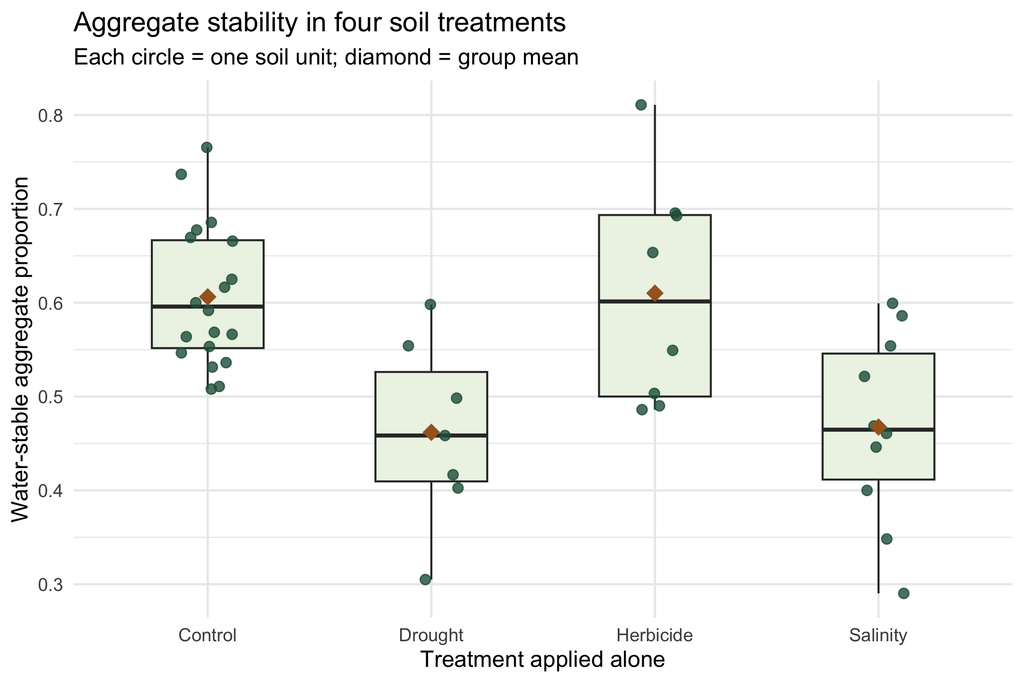

Drought and salinity have lower sample means than control; the herbicide mean is close to the control mean. Groups overlap and their spreads differ. Visual overlap alone does not answer a population-mean comparison. `outlier.shape = NA` hides duplicate boxplot symbols; **all observations remain present as circles and remain in the analysis**.

I checked the selected units, response-specific missingness, and raw group patterns.

## 3. ANOVA and comparisons

**Purpose:** distinguish “some means differ” from “this pair differs,” while accounting for multiple comparisons.

### A. The overall ANOVA

Our null hypothesis is **all four population mean WSA values are equal**. The alternative is that at least one differs. ANOVA compares variation among fitted group means with variation remaining within groups.

Use `group_data`, including its `treatment` factor, from the preceding treatment-inspection section. Fit the model before requesting its ANOVA table; the same fitted object is used for the Tukey comparisons below.

```r
group_model <- aov(WSA ~ treatment, data = group_data)
summary(group_model)
```

Find the treatment row, its F statistic, and `Pr(>F)`. Under the null model and its assumptions, the p-value measures how unusual an F statistic at least this large would be. It does not measure the probability that all means are equal or the size of an ecological effect.

**Check: what the overall result supports**

For this selection, **F(3, 41) ≈ 8.25, p ≈ 0.000207**. Under the model assumptions, the data provide evidence against a common mean across these four groups. This does **not** establish that every treatment differs from control, identify the differing pairs, or demonstrate ecological importance.

### B. Six comparisons form one family

Four groups give **six pairwise comparisons**. If we examine all six, separate unadjusted tests can increase the chance of at least one false positive. We use **Tukey comparisons** for this planned family. They provide mean differences, simultaneous confidence intervals, and adjusted p-values under the common-variance model.

```r
tukey_result <- TukeyHSD(group_model, conf.level = 0.95)
tukey_result

pairwise_table <- data.frame(
  comparison = rownames(tukey_result$treatment),
  tukey_result$treatment,
  row.names = NULL,
  check.names = FALSE
)
pairwise_table
```

Read each label as **first group minus second group**. For example, `Drought-Control` has the same direction as Day 2. The table columns are:

- **`diff`**: estimated mean difference in WSA proportion;
- **`lwr`, `upr`**: lower and upper limits of the Tukey interval;
- **`p adj`**: p-value adjusted for the family of six pairwise comparisons.

We can focus our written report on the three control comparisons **while retaining the six-pair adjustment**:

```r
control_comparisons <- pairwise_table[
  pairwise_table$comparison %in% c("Drought-Control", "Herbicide-Control", "Salinity-Control"),
]
control_comparisons
```

**Your task:** explain all three control comparisons using their estimated difference, interval and ecological units. Which interval includes zero? Why does that not demonstrate equal soil functioning?

**Check: magnitude, uncertainty and ecological meaning**

| Comparison | Difference in percentage points | Approximate Tukey 95% limits, percentage points | Adjusted p |
| --- | --- | --- | --- |
| Drought − Control | −14.4 | −25.4 to −3.5 | 0.0055 |
| Herbicide − Control | +0.4 | −10.0 to +10.8 | 0.9996 |
| Salinity − Control | −13.9 | −23.5 to −4.2 | 0.0022 |

Under the fitted model, drought and salinity have lower mean WSA than control, with intervals excluding zero. The herbicide estimate is close to zero, but its interval still permits differences in either direction that could matter ecologically. A large p-value does not establish equivalence; a suitable equivalence margin and analysis would be needed for that question.

To judge ecological importance, connect aggregate stability to relevant processes such as erosion resistance or water movement, compare the magnitude with natural variation and measurement precision, and consider persistence under field conditions. Statistical significance alone does not answer this.

The drought mean difference matches Day 2. Its interval and p-value differ because today’s model pools an error variance across four groups and adjusts a six-pair comparison family; Day 2 used a two-group Welch test. Do not expect a simple numerical conversion between the two methods.

I distinguished the overall test from pairwise estimates and explained the adjustment family.

Break · Save your script and take 10 minutes. Before continuing, explain why a categorical treatment and the number of factors are different predictors.

## 4. Linear regression: number of factors

**Purpose:** use a slope to describe how a response varies with a numerical predictor.

We now use the number of factors as a numerical predictor. **Across 0, 1, 2, 5 and 8 factors, how is proportional litter mass loss associated with the number of factors?**

At each factor level, different treatment units received random-drawn factor combinations. This lets us describe a broad association across the selected treatment units, but a count alone does not identify which factors were present or separate their contributions.

### Select and count the observations

`Lv = 0` identifies control units; `Lv = 1` identifies single-factor units. The CSV contains the same single-factor measurements twice: under their named treatments and under the summary label `"1"`. Use the labels below to include one copy of each record, alongside controls and the 2-, 5- and 8-factor units.

```r
regression_labels <- c("CT", "1", "2", "5", "8")
regression_raw <- soil_data[
  soil_data$Lv %in% c(0, 1, 2, 5, 8) &
    soil_data$remark %in% regression_labels, ]
table(regression_raw$Lv)

reg_keep <- complete.cases(regression_raw[, c("Decom", "Lv")])
reg_excluded_ids <- regression_raw$X[!reg_keep]
regression_data <- regression_raw[reg_keep, ]
rownames(regression_data) <- paste0("record_", regression_data$X)

nrow(regression_data)
table(regression_data$Lv)
reg_excluded_ids
str(regression_data[, c("Decom", "Lv")])
```

**Do:** record candidate and retained sample sizes, missing-response exclusions, and observed numbers of factors. Check that `Lv` is numerical rather than a factor. Keep other columns for context, but do not remove records because an unused variable is missing.

**Check: a different analysis population**

There are **260 candidate units** at 0, 1, 2, 5 and 8 factors: **20, 93, 47, 50 and 50**, respectively. Eight lack `Decom`, leaving **252 observed units**: **20, 91, 45, 49 and 47**, respectively. The excluded record IDs in column `X` are **187, 216, 229, 251, 297, 344, 349 and 356**.

At a given nonzero level, units can receive different factor identities. The regression summarises the selected controls, single-factor units and mixtures under one fitted line.

### Fit a straight line

```r
trend_model <- lm(Decom ~ Lv, data = regression_data)
summary(trend_model)
coef(trend_model)
confint(trend_model)

slope <- coef(trend_model)["Lv"]
slope_interval <- confint(trend_model)["Lv", ]
r_squared <- summary(trend_model)$r.squared
```

Read the model as **fitted mean mass-loss proportion = intercept + slope × number of factors**. The intercept and slope describe a straight-line summary. The numerical `Lv` term assumes the same mean change per additional factor across this range. That assumption is something to assess, not a fact established by typing the formula.

```r
trend_plot <- ggplot(regression_data, aes(x = Lv, y = Decom)) +
  geom_point(position = position_jitter(width = 0.10, height = 0, seed = 4),
             colour = "#245e49", alpha = 0.6, size = 2) +
  geom_smooth(method = "lm", formula = y ~ x, se = TRUE,
              colour = "#a56424", fill = "#e6d4b9") +
  scale_x_continuous(breaks = c(0, 1, 2, 5, 8)) +
  labs(x = "Number of factors", y = "Proportional litter mass loss",
       title = "Linear regression of litter mass loss",
       subtitle = paste(nrow(regression_data), "observed units; points jittered horizontally only")) +
  theme_minimal(base_size = 12)
trend_plot
```

**Do:** describe the fitted direction and the variation around the line. Are observations available at every integer number of factors between 0 and 8? Does the shaded band contain the middle 95% of individual observations?

**Check: line, observations and the shaded band**

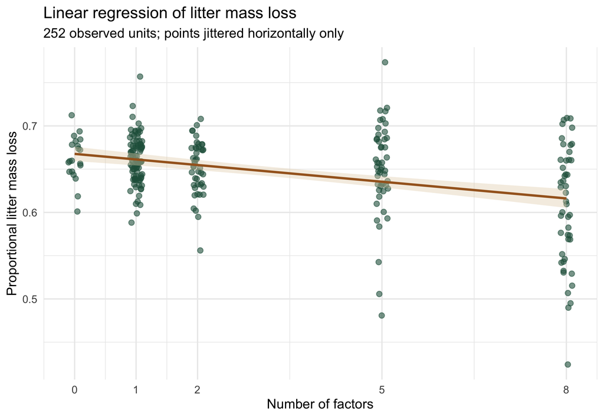

**Slope:** the fitted line associates each additional factor with approximately **0.00644 less proportional litter mass loss**, equivalent to **0.644 percentage points less mass loss**. The ordinary 95% slope interval is approximately **−0.00839 to −0.00448** proportion per factor.

**R²:** the fitted line accounts for about **14.4%** of the observed variation in litter mass loss (`R² ≈ 0.144`). Most variation remains around the line; R² describes the fit to these observations rather than forecast performance.

The intercept is the fitted mean at **`Lv = 0`**, approximately **0.668**. It can differ from the observed control mean (**0.662**) because the line is estimated from all 252 units.

The fitted line slopes down, while many observations differ substantially from it. We observed **0, 1, 2, 5 and 8 factors**; points appear slightly to either side because of plotting jitter. There are no observed 3-, 4-, 6- or 7-factor groups in this subset.

The shaded band is the ordinary model’s approximate **95% confidence band for the mean response at each predictor value**, not an interval containing 95% of individual observations or a simultaneous guarantee for the whole line. Its calibration depends on the model assumptions. An interval for a new individual soil unit would answer a different question and is usually wider.

I selected the regression data, fitted a numerical trend and distinguished a mean-response band from individual variation.

## 5. Your turn: linear regression with factor dissimilarity

**Independent task · 20 minutes.** Repeat the linear-regression workflow with the **same response, proportional litter mass loss (`Decom`)**, using the **factor dissimilarity index (`dissim`)** as the numerical predictor.

The supplied index describes differences among component factors using single-factor response profiles and is normalised within levels of the number of factors. Controls and single-factor units have `dissim = 0`.

### Fit the new regression

Check the variables used by this model and retain their complete rows. All **252** observations from Step 4 have a supplied dissimilarity value, so the two regressions use the same units.

```r
dissim_keep <- complete.cases(regression_data[, c("Decom", "dissim")])
dissim_excluded_ids <- regression_data$X[!dissim_keep]
dissim_data <- regression_data[dissim_keep, ]
nrow(dissim_data)

dissim_model <- lm(Decom ~ dissim, data = dissim_data)
summary(dissim_model)
confint(dissim_model)

dissim_slope <- coef(dissim_model)["dissim"]
dissim_interval <- confint(dissim_model)["dissim", ]
dissim_r_squared <- summary(dissim_model)$r.squared
```

Use the Step 4 plotting recipe to put `dissim` on the x-axis and `Decom` on the y-axis. Name your new plot `dissim_plot`.

**Supplied plotting recipe**

```r
dissim_plot <- ggplot(dissim_data, aes(x = dissim, y = Decom)) +
  geom_point(colour = "#245e49", alpha = 0.55, size = 2) +
  geom_smooth(method = "lm", formula = y ~ x, se = TRUE,
              colour = "#a56424", fill = "#e6d4b9") +
  labs(x = "Factor dissimilarity index", y = "Proportional litter mass loss",
       title = "Linear regression with factor dissimilarity",
       subtitle = paste(nrow(dissim_data), "observations; same litter mass loss response")) +
  theme_minimal(base_size = 12)
dissim_plot
```

Add three brief notes to your script:

1. Describe the slope.
2. Report R² and explain how much variation this model describes.
3. Compare the direction and R² with the number-of-factors regression from Step 4.

**Check: a possible dissimilarity interpretation**

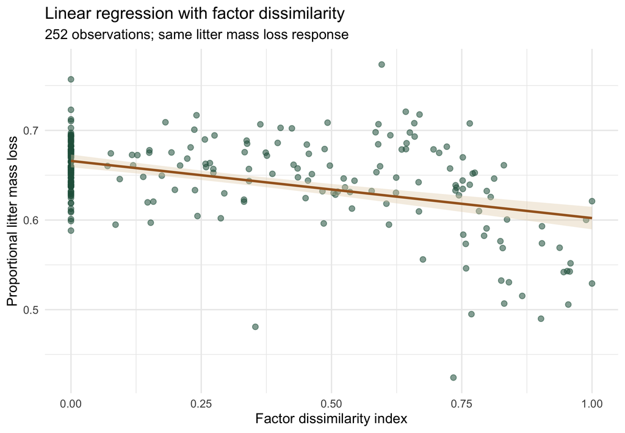

The slope is approximately **−0.06377 proportion per whole index unit**. A **0.1 increase** in the supplied index is associated with approximately **0.638 percentage points less litter mass loss**. The ordinary 95% slope interval is approximately **−0.07992 to −0.04761** proportion per index unit.

This model accounts for about **19.5%** of the observed variation (`R² ≈ 0.195`), compared with **14.4%** for the number-of-factors model on the same 252 units. Both fitted associations are negative. The higher R² describes a closer fit to these data; it does not establish causation or performance on new observations. This simple regression uses `dissim` as its only predictor; the first early-finisher question combines it with `Lv`.

I regressed litter mass loss on dissimilarity, made the plot, interpreted slope and R², and compared the two regressions.

## If you finish early: two thinking questions

### 1. Combine the two regression predictors

How does the fitted association with litter mass loss change when the **number of factors (`Lv`) and factor dissimilarity (`dissim`)** enter the same regression? Fit `Decom ~ Lv + dissim` and interpret the dissimilarity coefficient while holding the number of factors constant. Compare the fit with the number-of-factors model using the same observations.

The `+` specifies additive predictor terms. The supplied dissimilarity index is normalised within levels of the number of factors.

**Code: combine the predictors and compare the models**

```r
multiple_keep <- complete.cases(regression_data[, c("Decom", "Lv", "dissim")])
multiple_data <- regression_data[multiple_keep, ]
nrow(multiple_data)

count_only <- lm(Decom ~ Lv, data = multiple_data)
count_and_dissim <- lm(Decom ~ Lv + dissim, data = multiple_data)

summary(count_and_dissim)
confint(count_and_dissim)
anova(count_only, count_and_dissim)

model_fit_table <- data.frame(
  model = c("Count only", "Count plus dissimilarity"),
  n = c(nobs(count_only), nobs(count_and_dissim)),
  R_squared = c(summary(count_only)$r.squared,
                summary(count_and_dissim)$r.squared),
  adjusted_R_squared = c(summary(count_only)$adj.r.squared,
                         summary(count_and_dissim)$adj.r.squared)
)
model_fit_table
```

Why must the models use the same observations? Does a larger R² demonstrate better predictions for new soil units?

**Check: interpreting the combined model**

Both models use **252 observations**. The dissimilarity coefficient is approximately **−0.0518** per whole index unit: a **0.1 increase** is associated with about **0.518 percentage points less litter mass loss**, holding the number of factors constant under this additive model. The `Lv` coefficient also changes when dissimilarity is included.

The nested comparison requires the same response observations. R² increases from about **0.144 to 0.200**; adding a predictor cannot reduce ordinary R². Adjusted R² accounts for the number of estimated parameters, but neither measure establishes performance on new data. These fitted associations do not isolate causal effects of dissimilarity or individual factor identities.

### 2. How was the factor dissimilarity index calculated?

On **Day 3**, you compared fungal isolates using several standardised traits and distances between their trait profiles. Apply the same **trait-based approach** here: how was the factor dissimilarity index calculated for the **2-, 5- and 8-factor treatments**?

**Hint:** treat each individual global change factor like a fungal isolate, using its responses across the **seven measured soil functions as its trait profile**. Think back to trait scaling and distances on Day 3: how could differences between these profiles describe the dissimilarity of factors combined in a treatment?

## Help, downloads and references

**Something did not run?**

- **File not found:** extract the ZIP, open its project, then check `getwd()`, `list.files()` and `file.exists("MultiFactor_data.csv")`.
- **Object not found:** run earlier required commands in order. R is case-sensitive; `Lv` and `lv` are different names.
- **Package missing:** install `ggplot2` once and load it in every new session. Core work needs no `emmeans`, `car`, `broom`, `GGally` or `tidyverse` installation.
- **Wrong treatment counts:** select the explicit remark labels CT, D, H, S. Do not select the first four values returned by `unique()`.
- **Unexpected regression slope:** verify the response and subset. This lesson includes Lv 0, 1, 2, 5 and 8, selects labels CT/1/2/5/8 to avoid counting the single-factor records twice, and retains complete Decom/Lv records.
- **A strange missingness count:** inspect only variables needed for the current model. Do not apply `na.omit()` to every column of the original data frame.
- **Tukey output is missing:** run `aov()` on the factor `treatment` before `TukeyHSD()`. The spelling and capital letters matter.
- **Factor versus number:** `str()` checks how R stored the variable. The category names and the scientific question determine how it should enter the model; a numerical-looking label is not automatically a numerical trend.

Complete core R script Data dictionary Editable tutorial source

Use the reference script after attempting the tasks. If you use an AI assistant, ask it to explain a particular formula, output row or error, and verify its answer against your data and model. Your own interpretation should connect an estimate to ecological units and acknowledge a limitation.

**Data and research context:** the CSV is unchanged from the supplied Day 4 course file. The teaching selections and ordinary models are simplified exercises. See Bi et al. (2024), [*Number and dissimilarity of global change factors influences soil properties and functions*](https://doi.org/10.1038/s41467-024-52511-2), for the original study design, measurements and fuller analysis.

**R references:** [ANOVA with `aov()`](https://stat.ethz.ch/R-manual/R-devel/library/stats/html/aov.html), [Tukey comparisons](https://stat.ethz.ch/R-manual/R-devel/library/stats/html/TukeyHSD.html), [fitting linear models](https://stat.ethz.ch/R-manual/R-devel/library/stats/html/lm.html), [mean-response and prediction intervals](https://stat.ethz.ch/R-manual/R-devel/library/stats/html/predict.lm.html), and [comparing nested models](https://stat.ethz.ch/R-manual/R-devel/library/stats/html/anova.lm.html).

State the ecological question, read the effect in useful units, and check what the model leaves unexplained.